# APPs de Campina do Monte Alegre

NEEDS

05/2020

# Distribuição das APPs e Uso

### Uso do solo

O município de Campina do Monte Alegre possui área total de 18537Ha, distribuidos em seis classes de uso que podem ser observadas na tabela abaixo, com suas respectivas áreas totais.

|  | Classe de uso | Área (Ha) |
| --- | --- | --- |
| 0 | água | 271.2170 |
| 1 | área antropizada | 14063.5000 |
| 2 | área edificada | 106.2360 |
| 3 | formação florestal | 2078.7000 |
| 4 | formação não florestal | 73.8172 |
| 5 | silvicultura | 1925.9400 |

Na Figura a seguir pode-se observar como esta distribuida essas classes de uso, assim como a sua ocorrência dentro das áreas de preservação permanente(APP) do município de Campina do Monte Alegre.

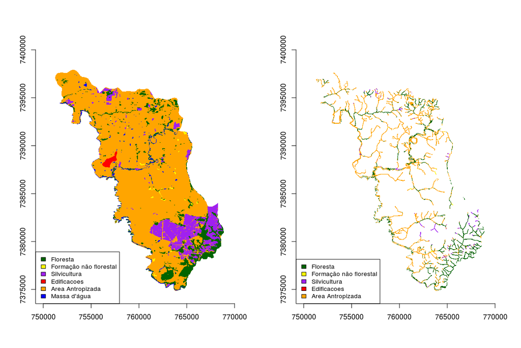

Figura 1. Uso e cobertura do solo do Município (esquerda) e a presença destas classes de uso dentro das áreas de APP´s (direita)

Na figura abaixo, encontra-se em destaque forma na qual as APP´s se distribuem, interligando fragmentos florestais existentes dentro do município, assim como o tamanho do curso d’água correspondente.

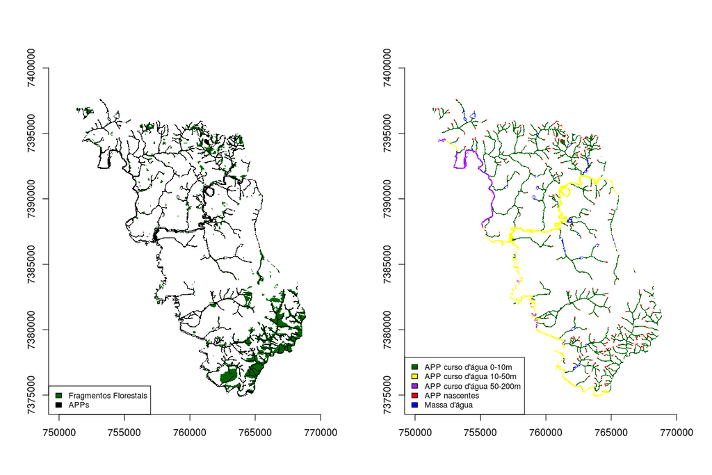

Figura 2. Fragmentos florestais e distribuição das APP’s dentro do município (esquerda) e quais tipos de corpos d’água compõe a rede (direita)

Existem, ao todo, 2254 hectáres de APP no município de Campina do Monte Alegre, na tabela abaixo é observado os valores em hectáres para cada uma das categorias apresentadas na Figura 2.

| curso d’água (0 - 10m) | curso d’água (10 - 50m) | curso d’água (50 - 200m) | massa d’água | nascente |
| --- | --- | --- | --- | --- |
| 1458.214 | 384.9328 | 135.4962 | 58.39721 | 216.8805 |

Já para as classes de uso apresentadas na Figura 1, a área está distribuida da seguinte forma:

| água | área antropizada | área edificada | formação florestal | formação não florestal | silvicultura |
| --- | --- | --- | --- | --- | --- |
| 0.0001827 | 1304.508 | 0.4909395 | 851.1724 | 12.83634 | 84.91236 |

### Valores de APP faltando

Dessa forma, contabilizando o total de APP existente e os diferentes usos existentes, estima-se que o total de APP a ser restaurado em Campina do Monte Alegre é de 1390 ha, o que corresponde a 62 % do total de APPs do município.  
Para ajudar em um possível processo de priorização de áreas para a recuperação é importante que os dados sejam mostrados de uma forma mais minuciosa. Com isso a seguir pode-se observar as proporções de uso dentro de cada tipo de APP mostrada anteriormente.

**Nascente**

|  | água | área antropizada | formação florestal | formação não florestal | silvicultura |
| --- | --- | --- | --- | --- | --- |
| Área (Ha) | 1.7e-06 | 149.04797 | 35.78399 | 1.2188649 | 30.82966 |
| (%) | 8.0e-07 | 68.72355 | 16.49941 | 0.5619984 | 14.21505 |

**Corpo d’água 0 - 10m**

|  | água | área antropizada | área edificada | formação florestal | formação não florestal | silvicultura |
| --- | --- | --- | --- | --- | --- | --- |
| Área (Ha) | 1.56e-05 | 800.05353 | 0.4909395 | 602.25630 | 11.0287845 | 44.384346 |
| (%) | 1.10e-06 | 54.86531 | 0.0336672 | 41.30096 | 0.7563214 | 3.043747 |

**Corpo d’água 10 - 50m**

|  | água | área antropizada | formação florestal | formação não florestal | silvicultura |
| --- | --- | --- | --- | --- | --- |
| Área (Ha) | 0.0001141 | 202.89479 | 176.19391 | 0.3350985 | 5.508892 |
| (%) | 0.0000296 | 52.70915 | 45.77264 | 0.0870538 | 1.431131 |

**Corpo d’água 50 - 200m**

|  | água | área antropizada | formação florestal | silvicultura |
| --- | --- | --- | --- | --- |
| Área (Ha) | 2.33e-05 | 99.69125 | 31.61550 | 4.189462 |
| (%) | 1.72e-05 | 73.57492 | 23.33312 | 3.091940 |

Com isso, temos:

- Nascente: O total de APP, dispostas em nascentes, a ser restaurado em Campina do Monte Alegre é de 180 ha, o que corresponde a 83 % do total de APPs presentes apenas em nascentes do município.
- Corpos d’água 0 - 10m: O total de APP, dispostas em corpos d’água 0 - 10m, a ser restaurado em Campina do Monte Alegre é de 845 ha, o que corresponde a 58 % do total de APPs presentes apenas em corpos d’água 0 - 10m do município.
- Corpos d’água 10 - 50m: O total de APP, dispostas em corpos d’água 10 - 50m, a ser restaurado em Campina do Monte Alegre é de 208 ha, o que corresponde a 54 % do total de APPs presentes apenas em corpos d’água 10 - 50m do município.
- Corpos d’água 50 - 200m: O total de APP, dispostas em corpos d’água 50 - 200m, a ser restaurado em Campina do Monte Alegre é de 104 ha, o que corresponde a 77 % do total de APPs presentes apenas em corpos d’água 50 - 200m do município.

### Perda/Recuperação florestal

Outro ponto importante é saber como funciona o padrão de perda e recuperação de áreas florestais, aqui é mostrada essa dinâmica em 10 anos, entre o período de 2007 e 2017.  
A Figura 3 ajuda a identificar regiões que talvez precisem de atenção pela crescente perda de vegetação dentro das APPs e também regiões favoráveis para a execução de projetos de recuperação e conservação.

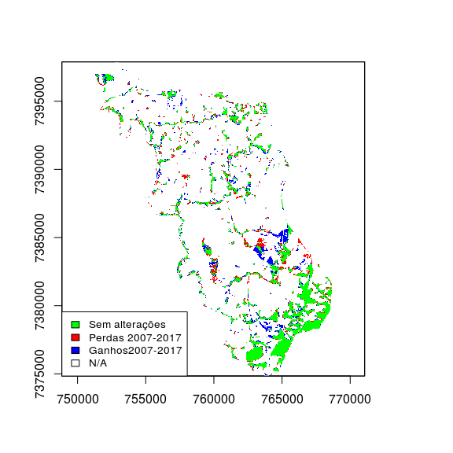

Figura 3. Alterações na vegetação entre os anos de 2007 e 2017

A work by [NEEDS](http://www.needs.ufscar.br/)

*needs.bio@gmail.com*